# 234

Versuch 234

```python
%matplotlib widget
import matplotlib.pyplot as plt
from matplotlib.lines import Line2D
import numpy as np
import scipy.constants as c
from scipy.optimize import curve_fit
from scipy.stats import chi2
from pathlib import Path
from adjustText import adjust_text
from matplotlib.widgets import Button

def figsize_cm(width_cm, height_cm):
    return (2*width_cm / 2.54, 2*height_cm / 2.54)
def comma_to_float(valstr):
    return float(valstr.replace(',','.'))
```

```python
base = Path.cwd()
Messwerte_path = Path(base.parent.parent.parent/"Messwerte"/"234")      # initializing paths
Ausgabe_path = Path(base/"Diagramme")
print(Messwerte_path)
print(Ausgabe_path)
```

```
c:\Users\samue\OneDrive\Dokumente\PAP\PAP2.1\Messwerte\234
c:\Users\samue\OneDrive\Dokumente\PAP\PAP2.1\Auswertungen\234\Code\Diagramme
```

Nr.1 Sonnenspektrum mit und ohne Glasfenster

```
(250.0, 900.0)
```

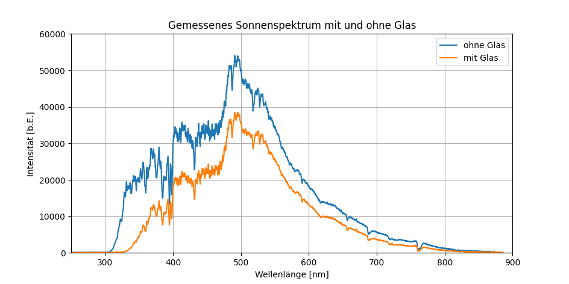

```python
lambda_ohneGlas, intensity_ohneGlas = np.loadtxt(Messwerte_path/"Nr.1"/"blauerhimmel_ohneglas.txt",skiprows=17,
converters= {0:comma_to_float, 1:comma_to_float},
comments='>', unpack=True)

lambda_mitGlas, intensity_mitGlas = np.loadtxt(Messwerte_path/"Nr.1"/"blauerhimmel_hinterglas.txt",skiprows=17,
converters= {0:comma_to_float, 1:comma_to_float},
comments='>', unpack=True)

plt.figure(figsize=figsize_cm(12,6))                            # Standard Plot erstellen, der gespeichert wird.
plt.plot(lambda_ohneGlas, intensity_ohneGlas, label='ohne Glas')
plt.plot(lambda_mitGlas, intensity_mitGlas, label='mit Glas')
plt.title('Gemessenes Sonnenspektrum mit und ohne Glas')
plt.xlabel('Wellenlänge [nm]')
plt.ylabel('Intensität [b.E.]')
plt.legend()
plt.grid()
plt.ylim((0,60000))
plt.xlim((250,900))
# plt.savefig(Ausgabe_path/"Nr.1_Himmel_m_o_G.png", format="png")
```

Nr.1.1 Absorption

```
(320.0, 800.0)
```

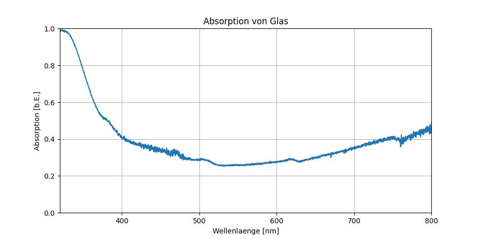

```python
A=1-intensity_mitGlas/intensity_ohneGlas

plt.figure(figsize=figsize_cm(12,6))
plt.plot(lambda_ohneGlas,A)
plt.title('Absorption von Glas')
plt.xlabel('Wellenlaenge [nm]')
plt.ylabel('Absorption [b.E.]')
plt.grid()
plt.ylim((0,1))
plt.xlim((320,800))
# plt.savefig(Ausgabe_path/"Nr.1_Absorption_Glas.png", format="png")
```

Nr.1.2 Hier wird es das erste Mal interessant: Sonnenspektrum mit Absorptionslinien und Balmer-Serie

```
9 [ 0.27475631 -0.89015311]
10 [-0.47846447 -0.01190192]
```

[figure not shown]

```python
lambda_sonneohneglas, intensity_sonneohneglas = np.loadtxt(Messwerte_path/"Nr.1"/"direktesonne_ohneglas.txt",skiprows=17,
converters= {0:comma_to_float, 1:comma_to_float},
comments='>', unpack=True)

bottom,top=plt.ylim()
plt.figure(figsize=figsize_cm(12,6))
plt.plot(lambda_sonneohneglas, intensity_sonneohneglas,)
plt.vlines(x=[394,397,412,431,486.8,517,527,589,616.5,656,687,760.5],ymin=0,ymax=max(bottom,top), colors='black', linewidths = 0.7, linestyle = 'dotted', label='geschätzte Absorptionslinien')
plt.title('Sonnenspektrum mit abgelesenen Absorptionslinien')
plt.xlabel('Wellenlänge [nm]')
plt.ylabel('Intensität [b.E.]')
plt.ylim((0,60000))
plt.xlim((350,800))
balmerserie = {                                                     # in dieser Liste werden die Namen der einzuzeichnenden Linien gespeichert
    r'$H_\alpha$': 656.1,
    r'$H_\beta$': 486.1,
    r'$H_\gamma$': 434,
    r'$H_\delta$': 410.1
}
plt.vlines(x=[410.1,434,486.1,656.1],ymin=0,ymax=40000, colors='red', linewidths = 0.7, label='Balmerserie')
for name, wl in balmerserie.items():                                # mit dieser Schleife werden die Linienlabels gesetzt
    if not wl==410.1:                                               # da sie übereinander liegen, werden manche bisschen verschoben
        plt.text(wl+2,15000,f"{name}\n({wl} nm)",color='red')
    else:
        plt.text(wl+2,24000,f"{name}\n({wl} nm)",color='red')
texts=[]
geschätzte_absorptionslinien=[394.6,398,411.4,431.5,435.2,486.8,517.7,527.5,586.4,589.9,589.9,656.6,687.5,760.8]        # mit der Maus erfasste Linien werden gespeichert
for i in geschätzte_absorptionslinien:                              # und gezeichnet
    t = plt.text(i, 50000, str(i), color="black", rotation=0,
    verticalalignment="bottom", horizontalalignment="left")
    texts.append(t)
adjust_text(texts)                                                  # soll labels automatisch uncolliding machen, klappt manchmal
plt.axvline(x=586.5,color='goldenrod',label='Helium (Lit. $\\lambda=487.6$nm)', linewidth=1)
plt.text(560,40000,str(486.5), color='goldenrod')
# plt.grid()
plt.legend()
# plt.savefig(Ausgabe_path/"Nr.1_Fraunhoferlinien.png", format="png")
```

Nr.1.2 Sonnenspektrum mit allen Fraunhoferlinien

```
9 [-0.12713059  0.1726091 ]
10 [-0.17357367 -0.64139173]
```

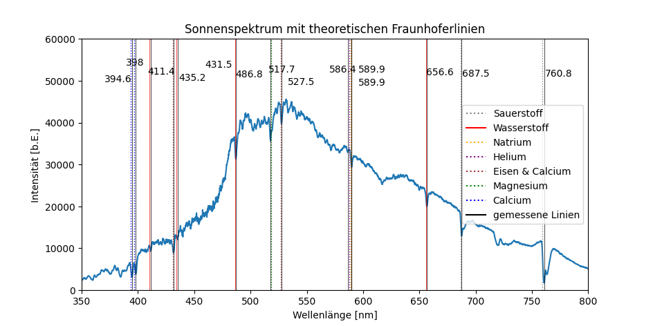

```python
plt.figure(figsize=figsize_cm(12,6))
plt.plot(lambda_sonneohneglas,intensity_sonneohneglas)
plt.title('Sonnenspektrum mit theoretischen Fraunhoferlinien')
plt.xlabel('Wellenlänge [nm]')
plt.ylabel('Intensität [b.E.]')
plt.xlim((350,800))
plt.ylim((0,60000))
fraunhofer_lines = {                                                # Zeichnen der restlichen Linien aus dem Skript-Anhang
"Sauerstoff": ("gray", [759.4, 686.7]),
"Wasserstoff": ("red", [656.1, 486.1,434.1,410.1]),
"Natrium": ("orange", [589.6, 589.0]),
"Helium": ("purple", [587.6]),
"Eisen & Calcium": ("brown", [527.0, 430.8]),
"Magnesium": ("green", [518.4]),
"Calcium": ("blue", [396.8, 393.4]),
}
handles=[]                                                          # nicht für jede Linienzahl ein Label erstellen, da die Elemente jeweils mehrere Werte haben
for element, (color, wavelengths) in fraunhofer_lines.items():
    for wavelength in wavelengths:
        if not element=='Wasserstoff':                              # Wasserstoff soll wie vorhin normal gestrichen sein
            plt.axvline(wavelength, color=color, linestyle="dotted",linewidth = 1)
        else:
            plt.axvline(wavelength, color=color, linewidth = 0.5)
for element, (color, _) in fraunhofer_lines.items():                # Item Einträge werden nur nach Element unterschieden, nicht nach Wellenlängen
    if not element=='Wasserstoff':
        handles.append(Line2D([0], [0], color=color, linestyle="dotted", label=element))    # für alle Elemente außer Wasserstoff soll im Legenden Handle die angezeigte Linie gestrichelt sein
    else:
        handles.append(Line2D([0], [0], color=color, label=element))

texts=[]
plt.vlines(x=geschätzte_absorptionslinien,ymin=0,ymax=max(bottom,top), colors='black', linewidths = 0.5, label='geschätzte Absorptionslinien')
for i in geschätzte_absorptionslinien:
    t = plt.text(i, 50000, str(i), color="black", rotation=0,
    verticalalignment="bottom", horizontalalignment="left")
    texts.append(t)
adjust_text(texts)
handles.append(Line2D([0], [0], color='black', label='gemessene Linien'))         # hinzufügen der letzten Handle
plt.legend(handles=handles,loc='center right')                                    # Handles Liste wird geplotted
# plt.savefig(Ausgabe_path/"Nr.1_Fraunhoferlinientheorethisch.png", format="png")
```

Nr.1.2 Ausgeben der LateX-Tabelle für gemessene und theoretische Fraunhoferlinien im Sonnenspektrum, berechnen der Sigma-Abweichung

```python
theoretische_Linien=[]
for element, (color, wavelengths) in fraunhofer_lines.items():
    for wavelength in wavelengths:
        theoretische_Linien.append(wavelength)
Theoretische_Linien=np.array(theoretische_Linien)
Theoretische_Linien.sort()
Geschätzte_absorptionslinien=np.array(geschätzte_absorptionslinien)
print(Theoretische_Linien)
print(Geschätzte_absorptionslinien)
sigma=np.round(abs(Theoretische_Linien-Geschätzte_absorptionslinien),1)
print(sigma)

for i,j,k in zip(Theoretische_Linien, Geschätzte_absorptionslinien, sigma):
    print(f"\\num{{{i}}}&\\num{{{j}}}&\\num{{{k}}}\\\\")
```

```
[393.4 396.8 410.1 430.8 434.1 486.1 518.4 527.  587.6 589.  589.6 656.1
 686.7 759.4]
[394.6 398.  411.4 431.5 435.2 486.8 517.7 527.5 586.4 589.9 589.9 656.6
 687.5 760.8]
[1.2 1.2 1.3 0.7 1.1 0.7 0.7 0.5 1.2 0.9 0.3 0.5 0.8 1.4]
\num{393.4}&\num{394.6}&\num{1.2}\\
\num{396.8}&\num{398.0}&\num{1.2}\\
\num{410.1}&\num{411.4}&\num{1.3}\\
\num{430.8}&\num{431.5}&\num{0.7}\\
\num{434.1}&\num{435.2}&\num{1.1}\\
\num{486.1}&\num{486.8}&\num{0.7}\\
\num{518.4}&\num{517.7}&\num{0.7}\\
\num{527.0}&\num{527.5}&\num{0.5}\\
\num{587.6}&\num{586.4}&\num{1.2}\\
\num{589.0}&\num{589.9}&\num{0.9}\\
\num{589.6}&\num{589.9}&\num{0.3}\\
\num{656.1}&\num{656.6}&\num{0.5}\\
\num{686.7}&\num{687.5}&\num{0.8}\\
\num{759.4}&\num{760.8}&\num{1.4}\\
```

Nr.2 verschiedenen Lichtquellen

```
Energiesparlampe&\num{573.91}\\
Glühlampe&\num{658.13}\\
Laser&\num{534.54}\\
LED_blau&\num{467.16}\\
LED_gelb&\num{594.17}\\
LED_rot&\num{630.93}\\
LED_weiß&\num{553.64}\\
LED_tageslichthell&\num{581.49}\\
LED_tageslichtdunkel&\num{586.92}\\
```

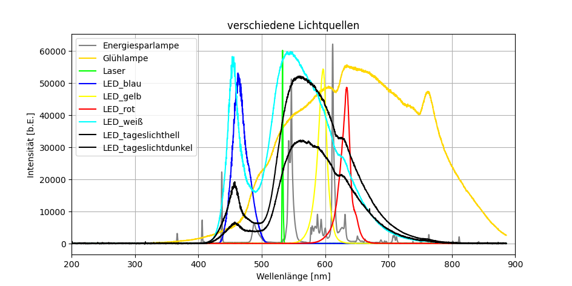

```python
# Lichtquellen-Liste mit entsprechender Farbzuteilung
lichtquellen={"Energiesparlampe":"grey","Glühlampe":"gold","Laser":"lime","LED_blau":"blue","LED_gelb":"yellow","LED_rot":"red","LED_weiß":"cyan","LED_tageslichthell":"black","LED_tageslichtdunkel":"black"}

plt.figure(figsize=figsize_cm(12,6))
plt.title('verschiedene Lichtquellen')
plt.xlabel('Wellenlänge [nm]')
plt.ylabel('Intensität [b.E.]')
plt.xlim((200,900))
for lichtquelle,color in lichtquellen.items():                                              # lade alle Lichtquellen automatisch als Funktion in den plot
    lambda_lichtquelle,intensity_lichtquelle  = np.loadtxt(Messwerte_path/"Nr.2"/f"{lichtquelle}.txt",skiprows=17,
    converters= {0:comma_to_float, 1:comma_to_float},
    comments='>', unpack=True)
    plt.plot(lambda_lichtquelle, intensity_lichtquelle,label=lichtquelle,color=color)       # könnte man safe auch wie unten irgendwie mit ax. und subplots und dann plt.show() machen, so klappt aber auch
    Lambda_lichtquelle=np.array(lambda_lichtquelle)                                         # erstellen der np Arrays zur Berechnung der mittleren Wellenlänge
    Intensity_lichtquelle=np.array(intensity_lichtquelle)
    meanlambda=round(np.sum(Lambda_lichtquelle*Intensity_lichtquelle)/np.sum(Intensity_lichtquelle),2)
    print(f"{lichtquelle}&\\num{{{meanlambda}}}\\\\")
plt.legend()
plt.grid()
# plt.savefig(Ausgabe_path/"Nr.2_Lichtquellen.png", format="png")
```

Hier geht der Abfuck los: für jedes aufgenommene Natriumspektrum wird ein Plot gezeichnet, und dann wurden per Hand die Emissionslinien gesucht, dies wurde eigentlich obsolet, da die Plots unten nochmal mit FHWM eingezeichnet wurden.

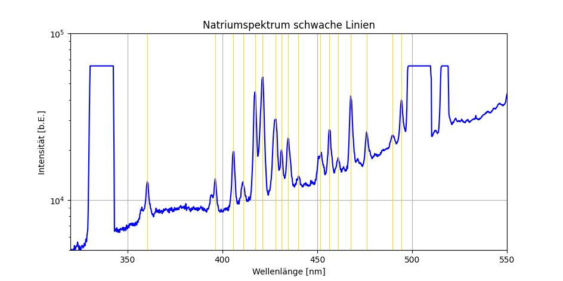

```python
lambda_natriumklein,intensity_natriumklein  = np.loadtxt(Messwerte_path/"Nr.3"/"Natriumdampflampe_kleinelinie.txt",skiprows=17,
converters= {0:comma_to_float, 1:comma_to_float},
comments='>', unpack=True)
color = 'blue'

natrium1klein = [360.5,396.3,405.8,411,417.2,421.2,428,431.2,434.6,440.1,451.7,456.4,461,467.6,476,489.7,494.3]
plt.figure(figsize=figsize_cm(12,6))
plt.title('Natriumspektrum schwache Linien')
plt.xlabel('Wellenlänge [nm]')
plt.ylabel('Intensität [b.E.]')
plt.yscale('log')
plt.ylim((5000,100000))
plt.xlim((320,550))
plt.plot(lambda_natriumklein, intensity_natriumklein,color=color)
plt.vlines(x=natrium1klein,ymin=0,ymax=100000, colors='gold', linewidths = 0.7)
plt.grid()
plt.savefig(Ausgabe_path/"Nr.3_Natriumspektrumkleinelinie.png", format="png")
```

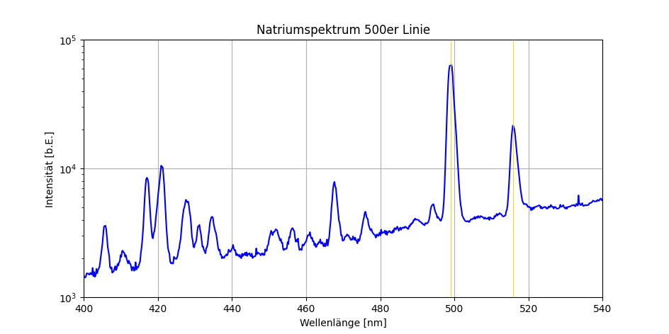

```python
lambda_natrium500,intensity_natrium500  = np.loadtxt(Messwerte_path/"Nr.3"/"Natriumdampflampe500linie.txt",skiprows=17,
converters= {0:comma_to_float, 1:comma_to_float},
comments='>', unpack=True)

Linien=[499,515.8]
plt.figure(figsize=figsize_cm(12,6))
plt.title('Natriumspektrum 500er Linie')
plt.xlabel('Wellenlänge [nm]')
plt.ylabel('Intensität [b.E.]')
plt.yscale('log')
plt.ylim((1000,100000))
plt.xlim((400,540))
plt.plot(lambda_natrium500, intensity_natrium500,color=color)
plt.vlines(x=Linien,ymin=0,ymax=1000000, colors='gold', linewidths = 0.7)
plt.grid()
plt.savefig(Ausgabe_path/"Nr.3_Natriumspektrum_500Linie.png", format="png")
```

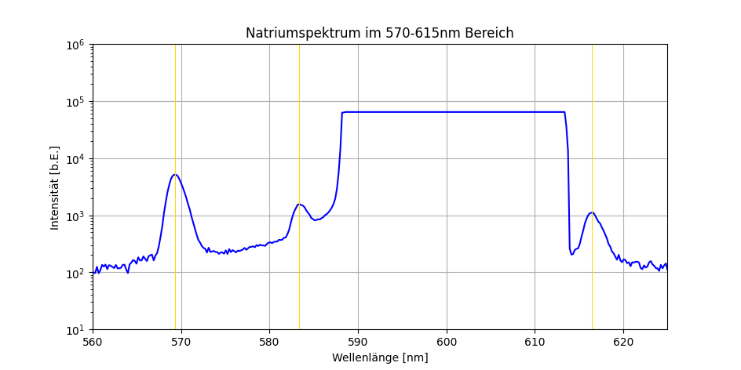

```python
lambda_natriumD,intensity_natriumD  = np.loadtxt(Messwerte_path/"Nr.4"/"natrium570-615.txt",skiprows=17,
converters= {0:comma_to_float, 1:comma_to_float},
comments='>', unpack=True)

Linien=[569.3,583.3,616.4]
plt.figure(figsize=figsize_cm(12,6))
plt.title('Natriumspektrum im 570-615nm Bereich')
plt.xlabel('Wellenlänge [nm]')
plt.ylabel('Intensität [b.E.]')
plt.yscale('log')
plt.ylim((10,1000000))
plt.xlim((560,625))
plt.plot(lambda_natriumD, intensity_natriumD,color=color)
plt.vlines(x=Linien,ymin=0,ymax=1000000, colors='gold', linewidths = 0.7)
plt.grid()
plt.savefig(Ausgabe_path/"Nr.3_Natriumspektrum_570-615Linien.png", format="png")
```

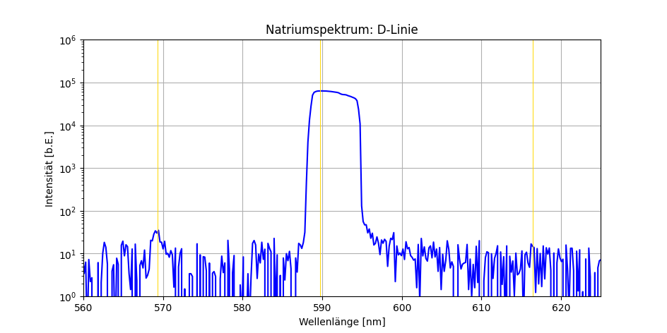

```python
lambda_natrium570_615,intensity_natrium570_615  = np.loadtxt(Messwerte_path/"Nr.4"/"NatriumD-Linie.txt",skiprows=17,
converters= {0:comma_to_float, 1:comma_to_float},
comments='>', unpack=True)

Linien=[569.3,616.4,589.7]
plt.figure(figsize=figsize_cm(12,6))
plt.title('Natriumspektrum: D-Linie')
plt.xlabel('Wellenlänge [nm]')
plt.ylabel('Intensität [b.E.]')
plt.yscale('log')
plt.ylim((1,1000000))
plt.xlim((560,625))
plt.plot(lambda_natrium570_615, intensity_natrium570_615,color=color)
plt.vlines(x=Linien,ymin=0,ymax=1000000, colors='gold', linewidths = 0.7)
plt.grid()
plt.savefig(Ausgabe_path/"Nr.3_Natriumspektrum_D-Linie.png", format="png")
```

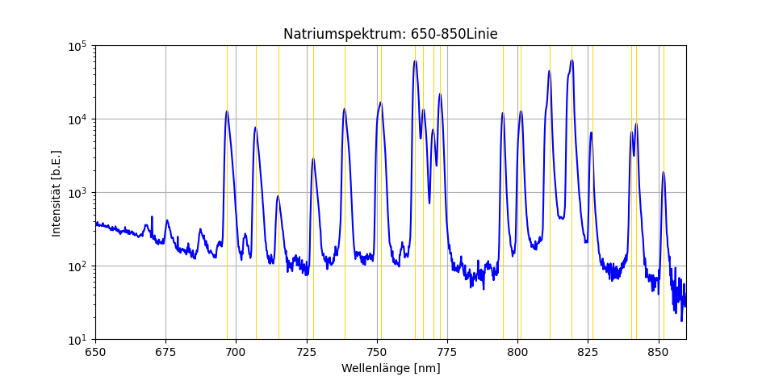

```python
lambda_natrium650_850,intensity_natrium650_850  = np.loadtxt(Messwerte_path/"Nr.5"/"Natrium650-850.txt",skiprows=17,
converters= {0:comma_to_float, 1:comma_to_float},
comments='>', unpack=True)

Linien=[696.7,706.9,715,727.5,738.5,751.4,763.6,766.5,770,772.5,794.7,801.2,811.3,819.3,826.6,840.5,842.2,851.8]
plt.figure(figsize=figsize_cm(12,6))
plt.title('Natriumspektrum: 650-850Linie')
plt.xlabel('Wellenlänge [nm]')
plt.ylabel('Intensität [b.E.]')
plt.yscale('log')
plt.ylim((10,100000))
plt.xlim((650,860))
plt.plot(lambda_natrium650_850, intensity_natrium650_850,color=color)
plt.vlines(x=Linien,ymin=0,ymax=1000000, colors='gold', linewidths = 0.7)
plt.grid()
plt.savefig(Ausgabe_path/"Nr.3_Natriumspektrum_650-850.png", format="png")
```

Ab hier kein Bock mehr, jetzt sollten auch noch FHWM als Fehler gesucht werden smh fuck me

Das war der Anfang vom Kochen mit ChatGPT:

- funktioniert nur für eine Datei.
- Linien sind vorgegeben
- FHWM wird berechnet durch klicken
- speichert nach Stop im Ordner der jpynb-Datei als peak_results.txt. Also keine Differenzierung nach Graph, sondern nur ein einziger fester Titel

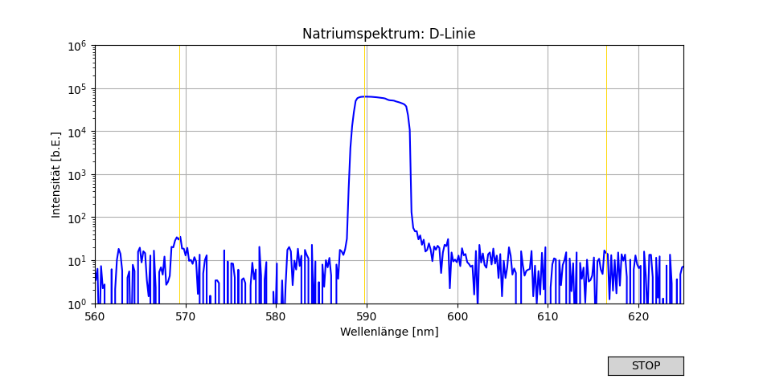

```python
# ----------------------------
# Messdaten laden
# ----------------------------
lambda_natrium570_615, intensity_natrium570_615 = np.loadtxt(
    Messwerte_path/"Nr.4"/"NatriumD-Linie.txt",
    skiprows=17,
    converters={0:comma_to_float, 1:comma_to_float},
    comments='>',
    unpack=True
)

Linien = [569.3, 616.4, 589.7]

# ----------------------------
# Figure und Plot
# ----------------------------
fig, ax = plt.subplots(figsize=figsize_cm(12,6))
plt.subplots_adjust(bottom=0.2)  # Platz für Button

ax.set_title('Natriumspektrum: D-Linie')
ax.set_xlabel('Wellenlänge [nm]')
ax.set_ylabel('Intensität [b.E.]')
ax.set_yscale('log')
ax.set_ylim((1,1000000))
ax.set_xlim((560,625))

ax.plot(lambda_natrium570_615, intensity_natrium570_615, color='blue')
ax.vlines(x=Linien, ymin=1, ymax=1000000, colors='gold', linewidths=0.7)
ax.grid()

# ----------------------------
# Variablen
# ----------------------------
clicks = []
results = []

# ----------------------------
# Datei speichern
# ----------------------------
def save_results_to_file(filename="peaks_results.txt"):
    with open(filename, "w") as f:
        for res in results:
            # Rundung auf eine Nachkommastelle
            peak = round(res['λ_peak']/2, 1)
            fwhm = round(res['FWHM'], 1)
            line = f"\\num{{{peak}({fwhm})}} \\\\\n"
            f.write(line)

# ----------------------------
# STOP-Button
# ----------------------------
def stop(event):
    # Button rot färben
    btn_stop.color = 'red'
    btn_stop.hovercolor = 'red'
    btn_stop.label.set_color('white')
    fig.canvas.draw_idle()

    save_results_to_file()
    # plt.close(fig)  # optional Plot schließen

ax_stop = plt.axes([0.8, 0.01, 0.1, 0.05])
btn_stop = Button(ax_stop, 'STOP', color='lightgray', hovercolor='gray')
btn_stop.on_clicked(stop)

# ----------------------------
# Klick-Event für Peaks
# ----------------------------
def onclick(event):
    if event.inaxes != ax or event.xdata is None:
        return

    clicks.append((event.xdata, event.ydata))

    if len(clicks) == 2:
        lambda_peak = clicks[0][0]                                              # clicks[0][0] nimmt aus dem nullten clicks-item (xdata, ydata) das nullte Element, beachte in der Informatik wird mit 0 angefangen
        I2 =  clicks[0][1]
        I1=0
        I_half = (I2 - I1)/2

        # Peak-Index im Array
        peak_index = np.argmin(np.abs(lambda_natrium570_615 - lambda_peak))

        # links vom Peak den Halbwertpunkt finden
        i = peak_index
        while i > 0 and intensity_natrium570_615[i] > I_half:
            i -= 1
        lambda1 = lambda_natrium570_615[i]

        # rechts vom Peak den Halbwertpunkt finden
        i = peak_index
        while i < len(intensity_natrium570_615)-1 and intensity_natrium570_615[i] > I_half:
            i += 1
        lambda2 = lambda_natrium570_615[i]

        fwhm = lambda2 - lambda1

        # Ergebnisse speichern
        results.append({
            'λ_peak': lambda_natrium570_615[peak_index],
            'λ1': lambda1,
            'λ2': lambda2,
            'FWHM': fwhm,
            'I_half': I_half
        })

        # Linien zeichnen
        ax.hlines(I_half, xmin=lambda1, xmax=lambda2, color="red", linestyle="--")
        ax.vlines(x=lambda1, ymin=I1, ymax=I2, color="green")
        ax.vlines(x=lambda2, ymin=I1, ymax=I2, color="green")
        fig.canvas.draw_idle()

        clicks.clear()  # bereit für nächsten Peak

fig.canvas.mpl_connect("button_press_event", onclick)
plt.show()
```

Das ist die finale Version für meine Anwendung. Es wird eine globale Funktion peak_analysis definiert.

- in graphs werden die Einstellungen zum Laden der 5 Diagramme vorgegeben
- nur FHWM wird eingezeichnet
- Werte werden gespeichert, unterm TeX_results Ordner als .txt Datei, je nachdem welche Messreihe man gerade analysiert.

```python
# ----------------------------
# Messdaten laden
# ----------------------------

graphs = [
    {
        "datei": Messwerte_path/"Nr.3"/"Natriumdampflampe_kleinelinie.txt",         # Dateipfad der Messwerte des Gitterspektrometers
        "Messreihe": "kleineLinien",                                                # Name der Messreihe (ist nicht derselbe Name wie der der Messwerte Datei), wird später genutzt, zum Erstellen des Plot-title, der TeX_results Datei, und als Name der .png Datei des fertigen Plots
        "xlim": (350, 550),                                                         # Wellenlängebereich der Messreihe
        "ylim": (5000, 100000),                                                     # Intensitätsbereich
        "Linien": [360.5,396.3,405.8,411,417.2,421.2,428,431.2,434.6,440.1,451.7,456.4,461,467.6,476,489.7,494.3]       # Werte der in den Python Codes von ganz am Anfang per Hand eingezeichneten Linien

    },
    {
        "datei": Messwerte_path/"Nr.3"/"Natriumdampflampe500linie.txt",
        "Messreihe": "500Linien",
        "xlim": (400, 540),
        "ylim": (1000,100000),
        "Linien": [499,515.8]

    },
    {
        "datei": Messwerte_path/"Nr.4"/"natrium570-615.txt",
        "Messreihe": "570-615Linien",
        "xlim": (560,625),
        "ylim": (10,1000000),
        "Linien": [569.3,583.3,616.4]
    },
    {
        "datei": Messwerte_path/"Nr.4"/"NatriumD-Linie.txt",
        "Messreihe": "DLinien",
        "xlim": (560,625),
        "ylim": (1,1000000),
        "Linien": [569.3,616.4,589.7]
    },
    {
        "datei": Messwerte_path/"Nr.5"/"Natrium650-850.txt",
        "Messreihe": "650-850Linien",
        "xlim": (650, 860),
        "ylim": (10, 100000),
        "Linien": [696.7,706.9,715,727.5,738.5,751.4,763.6,766.5,770,772.5,794.7,801.2,811.3,819.3,826.6,840.5,842.2,851.8]
    },
]

def peak_analysis(datei_path, Messreihe, Linien, xlim=(0,1000), ylim=(0,1e6)):      # die Argumente entsprechen den Einträgen der graphs-items (Einstellungen). Übergeben werden diese Einstellungen aber erst beim aufrufen der peak_analysis Funktion
    lambda_values, intensity_values = np.loadtxt(                                   # Laden der Spalten aus der Gitterdatei in zwei Arrays, die dann zum Plotten der I(\lambda) Kurve genutzt werden.
        datei_path,
        skiprows=17,
        converters={0:comma_to_float, 1:comma_to_float},
        comments='>',
        unpack=True
    )

    results = []                                                                    # erstellen der results-List, in der die Ergebnisse für TeX_results gespeichert werden

    # ---------------- Plot ----------------
    fig, ax = plt.subplots(figsize=(12,6))                                          # erstellen der figure (fig) und der Achsen (ax)
    plt.subplots_adjust(bottom=0.2)
    ax.plot(lambda_values, intensity_values, color='blue')                          # I(\lambda) (zwei Spalten aus der Gitterdatei) werden geplottet
    ax.set_xlim(xlim)                                                               # laden des ylim-Arguments von peak_analysis
    ax.set_ylim(ylim)                                                               # ""
    ax.set_yscale('log')
    ax.set_xlabel("Wellenlänge [nm]")
    ax.set_ylabel("Intensität [b.E.]")
    ax.set_title(f"Natriumspektrum: {Messreihe}")                                   # Plottitel anhand des Messreihen arguments von peak_analysis wird festgelegt
    ax.vlines(x=Linien, ymin=ylim[0], ymax=ylim[1], colors='gold', linewidths=0.7)  # Emissiosnlinien werden geplottet, vom 0.Argument von ylim bis zum 1. Argument von ylim
    ax.grid()

    clicks = []                                                                     # erstellen der clicks Liste, in der die FHWM Klicks gespeichert werden

    ax_btn_stop = plt.axes([0.7, 0.01, 0.2, 0.05])                                      # Positionieren des Buttons relativ zu den Plot-Achsen
    btn_stop = Button(ax_btn_stop, 'Press to stop measuring', color='lightgray', hovercolor='gray')        # Erstellen des Buttons btn_stop

    # ---------------- Klick-Event ----------------                                 # Klicken zur Berechnung/Einzeichnung der FHWM
    def onclick(event):
        if event.button != 1:        # nur Linksklick
            return
        if event.inaxes != ax or event.xdata is None:
            return
        # Toolbar-Interaktion ignorieren (Zoom oder Pan)
        if plt.get_current_fig_manager().toolbar.mode != '':
            return

        clicks.append((event.xdata, event.ydata))                                   # füllen der clicks Liste mit den Positionsdaten des Mauszeigers ('click'-event.xdata)
        if len(clicks) == 2:                                                        # nach zweimal drücken (also auf dem Untergrund des Peaks und dem Peak selber) wird berechnet
            lambda_peak = clicks[1][0]                                              # clicks[1][0] nimmt aus dem ersten clicks-item (xdata, ydata) das nullte Element, beachte in der Informatik wird mit 0 angefangen
            I1, I2 = clicks[0][1], clicks[1][1]
            I_half = I1 + (I2 - I1)/2
            peak_index = np.argmin(np.abs(lambda_values - lambda_peak))             # da im Plot kontinuierliche Werte angezeigt werden, wird der nächste Datenpunkt aus der Gitterspalten Datei gesucht

            # suchen nach der linken Wellenlänge der FHWM
            i = peak_index
            while i > 0 and intensity_values[i] > I_half:                           # für 0 < lambda < lambda_peak bis zu I(lambda)=I_half läuft die Schleife
                i -= 1
            lambda1 = lambda_values[i]                                              # lambda_1 (links) wurde gefunden

            # suchen nach der rechten Wellenlänge der FHWM
            i = peak_index
            while i < len(intensity_values)-1 and intensity_values[i] > I_half:     # für lambda > lambda_peak < maxlambdausderDatei und I(lambda) > I_half wird gesucht
                i += 1
            lambda2 = lambda_values[i]                                              # lambda_2 (rechts) wurde gefunden

            fwhm = lambda2 - lambda1                                                # berechnen der FHWM

            results.append({                                                        # eintragen der Rechenwerte in die results Liste
                'λ_peak': lambda_values[peak_index],
                'λ1': lambda1,
                'λ2': lambda2,
                'FWHM': fwhm,
                'I_half': I_half
            })

            ax.hlines(I_half, xmin=lambda1, xmax=lambda2, color="red")              # Zeichnen der FHWM
            ax.vlines(x=lambda1, ymin=I1, ymax=I_half, color="green")
            ax.vlines(x=lambda2, ymin=I1, ymax=I_half, color="green")
            fig.canvas.draw_idle()                                                  # keine Ahnung was das macht, irgendwie timet dies das Neuzeichnen der Grafik, wenn es die richtigen Resourcen gibt

            clicks.clear()                                                          # es wird immer nur ein Klick gespeichert, sodass man mit harten Zahlen bei I_1=clicks[0][1] arbeiten kann

    # ---------------- Speichern ----------------
    def save_results_to_file(filename=f"Natrium_{Messreihe}_TeXresults.txt"):       # speichern der TeX_results Datei, anhand der Messreihen-Einstellung wird der filename festgelegt
        filepath = base/"TeX_results"/ filename                                     # anhand des filenames wird der Speicherpfad festgelegt, relativ zu base (wurde am Anfang als Ort der jpynb Datei definiert)
        with open(filepath, "w") as f:                                              # results.txt wird als f geöffnet
            for res in results:                                                     # für alle Items in der results Liste
                peak = round(res['λ_peak'], 1)                                      # werden die zwei in der .write benötigten Variablen benannt und mit den results Listenwerten belegt
                fwhm = round(res['FWHM']/2, 1)
                f.write(f"\\num{{{peak}({fwhm})}} \\\\\n")                          # für alle Einträge in der results Liste wird eine Zeile in die results.txt geschrieben

    # ---------------- STOP-Button ----------------
    def stop(event):                                                                # wenn man mit auswählen aller peaks fertig ist, stop drücken, danach wird alles gespeichert
        fig.canvas.mpl_disconnect(cid)
        btn_stop.color = 'red'
        btn_stop.hovercolor = 'red'
        btn_stop.label.set_text('Measuring done')
        fig.canvas.draw_idle()
        save_results_to_file()
        # plt.close(fig)  # optional
        fig.savefig(Ausgabe_path/f"Nr.3_{Messreihe}_FHWM.png", format="png")

    btn_stop.on_clicked(stop)                                                       # wird der Button gedrückt (also die .on_clicked-Aktion), wird die Stop Funktion ausgeführt
    cid = fig.canvas.mpl_connect("button_press_event", onclick)                     # bei jedem Klick wird neu gezeichnet
    plt.show()
```

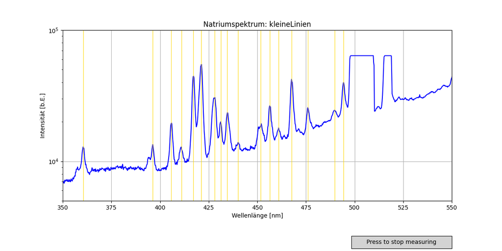

```python
index_graph = 0
peak_analysis(graphs[index_graph]["datei"], graphs[index_graph]["Messreihe"], graphs[index_graph]["Linien"], graphs[index_graph]["xlim"], graphs[index_graph]["ylim"])
```

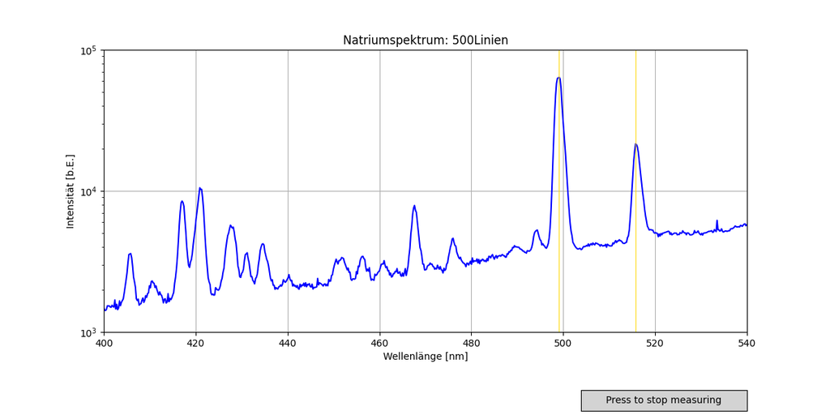

```python
index_graph = 1
peak_analysis(graphs[index_graph]["datei"], graphs[index_graph]["Messreihe"], graphs[index_graph]["Linien"], graphs[index_graph]["xlim"], graphs[index_graph]["ylim"])
```

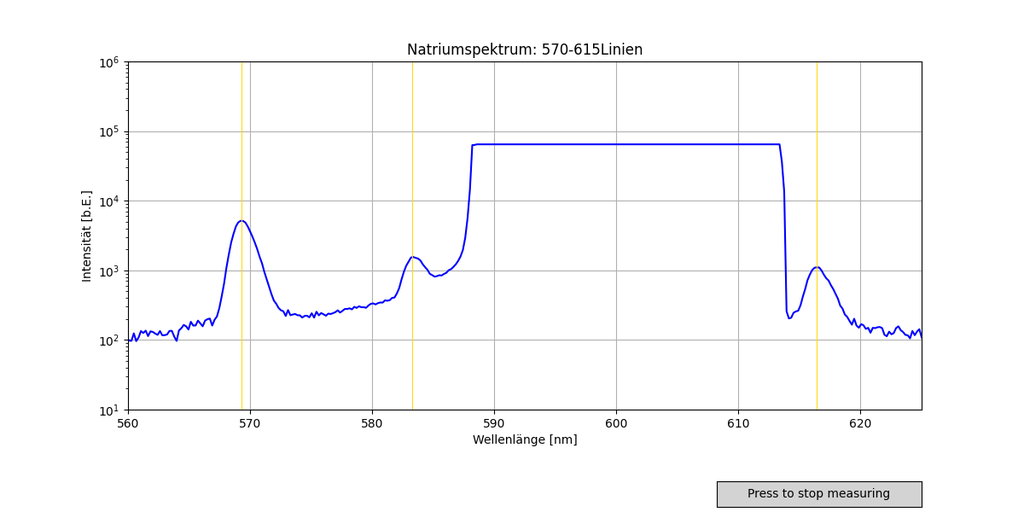

```python
index_graph = 2
peak_analysis(graphs[index_graph]["datei"], graphs[index_graph]["Messreihe"], graphs[index_graph]["Linien"], graphs[index_graph]["xlim"], graphs[index_graph]["ylim"])
```

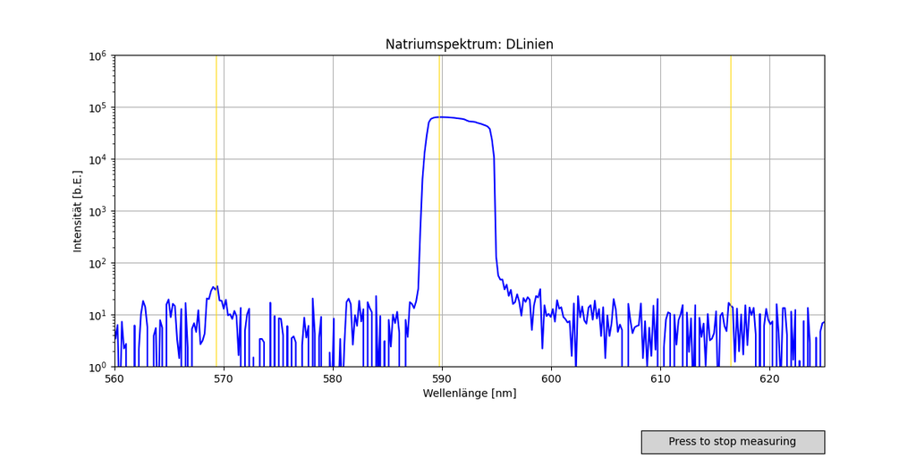

```python
index_graph = 3
peak_analysis(graphs[index_graph]["datei"], graphs[index_graph]["Messreihe"], graphs[index_graph]["Linien"], graphs[index_graph]["xlim"], graphs[index_graph]["ylim"])
```

[figure not shown]

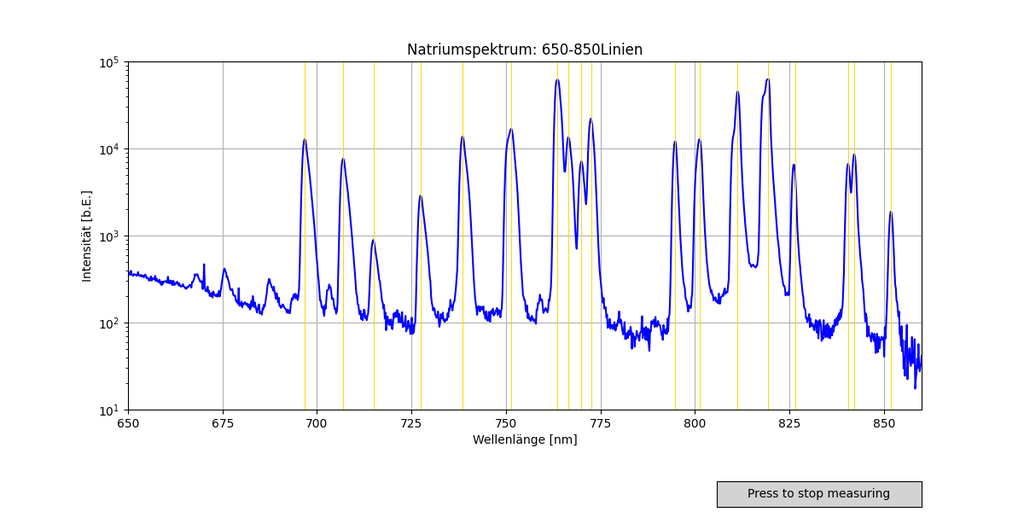

```python
index_graph = 4
peak_analysis(graphs[index_graph]["datei"], graphs[index_graph]["Messreihe"], graphs[index_graph]["Linien"], graphs[index_graph]["xlim"], graphs[index_graph]["ylim"])
```

Nr.3 Berechnen der Nebenserien

Erwartete Linien für die 1. Nebenserie: md → 3p

```python
#Berechnen von E_3p
RyE = -1*c.h*c.c*c.Rydberg/c.eV
m = 3
lamb_3 = 819
Delta_lamb_3 = 1.5
E_3p = RyE/ m**2 - c.h * c.c /c.eV / (lamb_3*1e-9)
Delta_E_3p = c.h * c.c / c.eV / (lamb_3*1e-9)**2 * Delta_lamb_3*1e-9
print(f'E_3p={round(E_3p,4)}, {round(Delta_E_3p,4)}')

def lamb_m(m):
    lamb = c.h * c.c/ c.eV / (RyE/ m**2 - E_3p)*1e9
    Delta_lamb = c.h * c.c * Delta_E_3p * c.eV / (RyE * c.eV / m**2 - E_3p * c.eV)**2 * 1e9
    return lamb, Delta_lamb

nebenserie1 = []
for m in range(3,14):
    l, k = lamb_m(m)
    nebenserie1.append((l,k))
    print(f'm={m:2d}, lambda = {round(nebenserie1[m-3][0],1)} ± {round(nebenserie1[m-3][1],1)}')

for m in range(3,14):
    print(f'{m}&\\num{{{round(nebenserie1[m-3][0],1)}({round(nebenserie1[m-3][1],1)})}}')
```

```
E_3p=-3.0256, 0.0028
m= 3, lambda = 819.0 ± 1.5
m= 4, lambda = 570.0 ± 0.7
m= 5, lambda = 499.7 ± 0.6
m= 6, lambda = 468.3 ± 0.5
m= 7, lambda = 451.2 ± 0.5
m= 8, lambda = 440.8 ± 0.4
m= 9, lambda = 433.9 ± 0.4
m=10, lambda = 429.1 ± 0.4
m=11, lambda = 425.6 ± 0.4
m=12, lambda = 423.0 ± 0.4
m=13, lambda = 421.0 ± 0.4
3&\num{819.0(1.5)}
4&\num{570.0(0.7)}
5&\num{499.7(0.6)}
6&\num{468.3(0.5)}
7&\num{451.2(0.5)}
8&\num{440.8(0.4)}
9&\num{433.9(0.4)}
10&\num{429.1(0.4)}
11&\num{425.6(0.4)}
12&\num{423.0(0.4)}
13&\num{421.0(0.4)}
```

Erwartete Linien für die 2. Nebenserie: ms → 3p

```python
lamb_D=589
Delta_lamb_D = 1.5
E_3s = E_3p-c.c*c.h/(c.eV*lamb_D*1e-9)
Delta_E_3s = np.sqrt((Delta_E_3p)**2 + (1.2398e3/(lamb_D)**2 * (Delta_lamb_D))**2)
print(f'E_3s={round(E_3s,3)},{round(Delta_E_3s,4)}')

korrs = 3-np.sqrt(RyE/E_3s)
Delta_korrs =np.sqrt(RyE/E_3s**3)*Delta_E_3s/2
print(f'korrs={round(korrs,4)},{round(Delta_korrs,4)}')

def lamb_m(m):
    lamb = c.h * c.c / c.eV  / (RyE/ (m-korrs)**2 - E_3p)*1e9
    Delta_lamb = np.sqrt(((-2*RyE*c.c*c.eV*c.h/((-korrs + m)**3*(-E_3p*c.eV+RyE*c.eV/(-korrs + m)**2)**2))*Delta_korrs)**2 + ((c.c*c.eV*c.h/(-E_3p*c.eV+ RyE*c.eV/(-korrs + m)**2)**2)*Delta_E_3p)**2)*1e9
    return lamb, Delta_lamb

nebenserie2 = []
for m in range(4,10):
    l, k = lamb_m(m)
    nebenserie2.append((l,k))
    print(f'm={m:2d}, lambda = {round(nebenserie2[m-4][0],1)} ± {round(nebenserie2[m-4][1],1)}')

for m in range(4,10):
    print(f'{m}&\\num{{{round(nebenserie2[m-4][0],1)}({round(nebenserie2[m-4][1],1)})}}')
```

```
E_3s=-5.131,0.006
korrs=1.3715,0.001
m= 4, lambda = 1173.8 ± 3.5
m= 5, lambda = 622.4 ± 0.9
m= 6, lambda = 518.7 ± 0.6
m= 7, lambda = 477.6 ± 0.5
m= 8, lambda = 456.5 ± 0.5
m= 9, lambda = 444.1 ± 0.4
4&\num{1173.8(3.5)}
5&\num{622.4(0.9)}
6&\num{518.7(0.6)}
7&\num{477.6(0.5)}
8&\num{456.5(0.5)}
9&\num{444.1(0.4)}
```

Erwartete Linien für die Hauptserie: mp → 3s

```python
korrp = 3-np.sqrt(RyE/E_3p)
Delta_korrp =np.sqrt(RyE/E_3p**3)*Delta_E_3p
print(f'korrs={round(korrp,4)},{round(Delta_korrp,4)}')

def lamb_m(m):
    lamb = c.h * c.c / c.eV / (RyE / (m-korrp)**2 - E_3s)*1e9
    Delta_lamb = np.sqrt(((-2*RyE*c.c*c.eV*c.h/((-korrp + m)**3*(-E_3s*c.eV +RyE*c.eV/(-korrp + m)**2)**2))*Delta_korrp)**2 + ((c.c*c.eV*c.h/(-E_3s*c.eV+ RyE*c.eV/(-korrp + m)**2)**2)*Delta_E_3s)**2)*1e9
    return lamb, Delta_lamb

hauptserie = []
for m in range(4,6):
    l, k = lamb_m(m)
    hauptserie.append((l,k))
    print(f'm={m:2d}, lambda = {round(hauptserie[m-4][0],1)} ± {round(hauptserie[m-4][1],1)}')

for m in range(4,6):
    print(f'{m}&\\num{{{round(hauptserie[m-4][0],1)}({round(hauptserie[m-4][1],1)})}}')
```

```
korrs=0.8794,0.0019
m= 4, lambda = 332.1 ± 0.6
m= 5, lambda = 286.4 ± 0.4
4&\num{332.1(0.6)}
5&\num{286.4(0.4)}
```

Berechnung der Sigma-Abweichungen die data-Felder sind die zugeordneten Zeilen aus der LateX-Tabelle, in denen die berechneten und aus den Plots extrahierten Emissionslinien von Natrium eingetragen wurden.

```python
import re
import math

data1 = """
3&\\num{819.0(1.5)}&\\num{819.1(1.1)} \\
4&\\num{570.0(0.7)}&\\num{569.2(1.0)} \\
5&\\num{499.7(0.6)}&\\num{498.9(1.0)} \\
6&\\num{468.3(0.5)}&\\num{467.6(0.9)} \\
7&\\num{451.2(0.5)}&\\num{452.2(1.7)} \\
8&\\num{440.8(0.4)}&\\num{439.7(1.1)} \\
9&\\num{433.9(0.4)}&\\num{434.7(1.0)} \\
10&\\num{429.1(0.4)}&\\num{428.2(1.4)} \\
13&\\num{421.0(0.4)}&\\num{421.1(1.1)}&\\
"""

pattern = r'\\num{([\d.]+)\(([\d.]+)\)}'
patternm = r'^(\d+)'


nebenserie1_wellen=[]
nebenserie1_wellenfehler=[]
nebenserie1m=[]
for line in data1.strip().splitlines():
    matches = re.findall(pattern, line)
    matchm = re.search(patternm, line)
    if len(matches) == 2 and matchm:
        m = int(matchm.group(1))
        val1, err1 = map(float, matches[0])
        val2, err2 = map(float, matches[1])
        nebenserie1_wellen.append(val2)
        nebenserie1_wellenfehler.append(err2)
        nebenserie1m.append(m)
        sigma = abs(val1 - val2) / math.sqrt(err1**2 + err2**2)
        print(f"&{sigma:.2f}")


Nebenserie1_wellen=np.array(nebenserie1_wellen)
Nebenserie1_wellenfehler=np.array(nebenserie1_wellenfehler)
Nebenserie1m=np.array(nebenserie1m)
print(Nebenserie1m)
print(Nebenserie1_wellen)
print(Nebenserie1_wellenfehler)

print()

data2=  """
5&\\num{622.4(0.9)}&\\num{616.2(0.4)} \\
6&\\num{518.7(0.6)}&\\num{515.8(1.0)} \\
7&\\num{477.6(0.5)}&\\num{475.8(1.1)} \\
8&\\num{456.5(0.5)}&\\num{456.0(1.0)} \\
9&\\num{444.1(0.4)}&\\num{439.7(1.1)} \\
"""

nebenserie2_wellen=[]
nebenserie2_wellenfehler=[]
nebenserie2m=[]
for line in data2.strip().splitlines():
    matches = re.findall(pattern, line)
    matchm = re.search(patternm, line)
    if len(matches) == 2 and matchm:
        m = int(matchm.group(1))
        val1, err1 = map(float, matches[0])
        val2, err2 = map(float, matches[1])
        nebenserie2_wellen.append(val2)
        nebenserie2_wellenfehler.append(err2)
        nebenserie2m.append(m)
        sigma = abs(val1 - val2) / math.sqrt(err1**2 + err2**2)
        print(f"&{sigma:.2f}")

Nebenserie2_wellen=np.array(nebenserie2_wellen)
Nebenserie2_wellenfehler=np.array(nebenserie2_wellenfehler)
Nebenserie2m=np.array(nebenserie2m)
print(Nebenserie2m)
print(Nebenserie2_wellen)
print(Nebenserie2_wellenfehler)
```

```
&0.05
&0.66
&0.69
&0.68
&0.56
&0.94
&0.74
&0.62
&0.09
[ 3  4  5  6  7  8  9 10 13]
[819.1 569.2 498.9 467.6 452.2 439.7 434.7 428.2 421.1]
[1.1 1.  1.  0.9 1.7 1.1 1.  1.4 1.1]

&6.30
&2.49
&1.49
&0.45
&3.76
[5 6 7 8 9]
[616.2 515.8 475.8 456.  439.7]
[0.4 1.  1.1 1.  1.1]
```

Fitten der gemessenen Ergebnisse aus der Natriumtabelle der ersten Nebenserie

```
E_Ry= -13.312622836061621 , Standardfehler= 0.2309511947591827
E_3p= -3.023694832517033 , Standardfehler= 0.003775784601552789
D_d= 0.03088361539955528 , Standardfehler= 0.02276220634648546
chi2= 2.5349938374137855
chi2_red= 0.4224989729022976
Wahrscheinlichkeit: 86.0 %
```

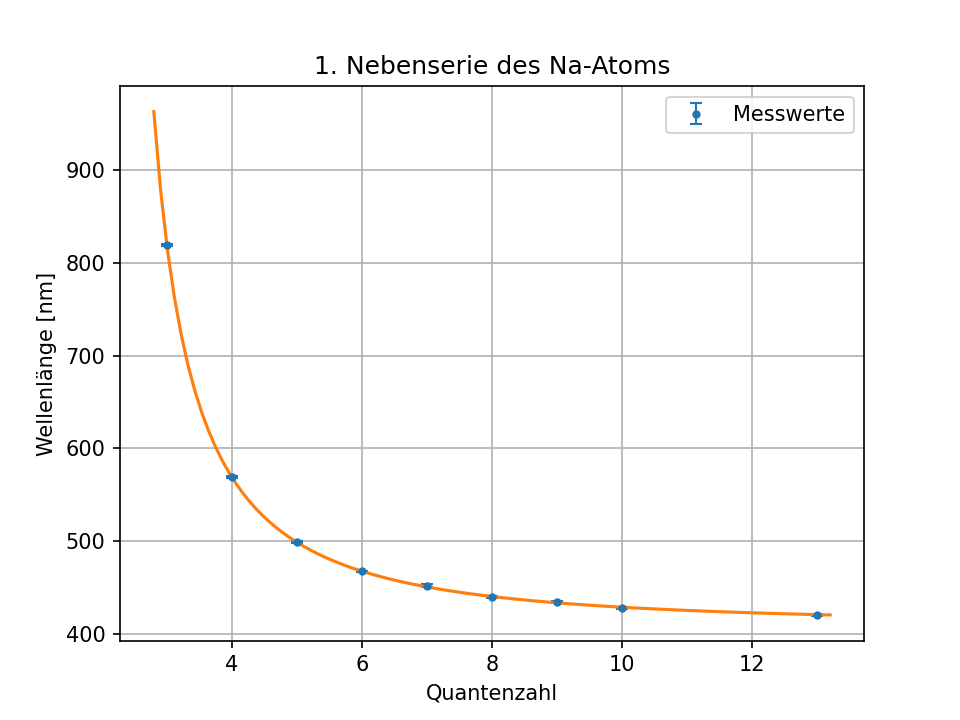

```python
def fit_func1(m,E_Ry,E_3p,D_d):
    return 1.2398E3/(E_Ry/(m-D_d)**2-E_3p)
para = [-13.6,-3,-0.02]
popt, pcov = curve_fit(fit_func1,Nebenserie1m,Nebenserie1_wellen,sigma=Nebenserie1_wellenfehler,p0=para)
x=np.linspace(2.8,13.2, 100)

plt.figure(dpi=150)
plt.errorbar(Nebenserie1m,Nebenserie1_wellen,yerr=Nebenserie1_wellenfehler,fmt=".",capsize=3,elinewidth=1,label='Messwerte')
plt.plot(x,fit_func1(x,*popt))
plt.xlabel('Quantenzahl')
plt.ylabel('Wellenlänge [nm]')
plt.title('1. Nebenserie des Na-Atoms')
plt.legend()
plt.grid()
plt.savefig(Ausgabe_path/"Nr.3_Nebenserie1.png", format="png")

print("E_Ry=",popt[0], ", Standardfehler=", np.sqrt(pcov[0][0]))
print("E_3p=",popt[1], ", Standardfehler=", np.sqrt(pcov[1][1]))
print("D_d=",popt[2], ", Standardfehler=", np.sqrt(pcov[2][2]))

chi2_=np.sum((fit_func1(Nebenserie1m,*popt)- Nebenserie1_wellen)**2/ Nebenserie1_wellenfehler**2)
dof=len(Nebenserie1m)-3 #dof:degrees of freedom, Freiheitsgrad
chi2_red=chi2_/dof
print("chi2=", chi2_)
print("chi2_red=",chi2_red)

prob=round(1-chi2.cdf(chi2_,dof),2)*100
print("Wahrscheinlichkeit:", prob,"%")
```

Fitten der zweiten Nebenserie

```
E_Ry= -15.424418960685733 , Standardfehler= 2.491190299549173
E_3p= -3.0596767847265967 , Standardfehler= 0.03237167290981489
D_s= 1.1628769594041732 , Standardfehler= 0.25291932741264594
chi2= 6.302600904126201
chi2_red= 3.1513004520631007
Wahrscheinlichkeit: 4.0 %
```

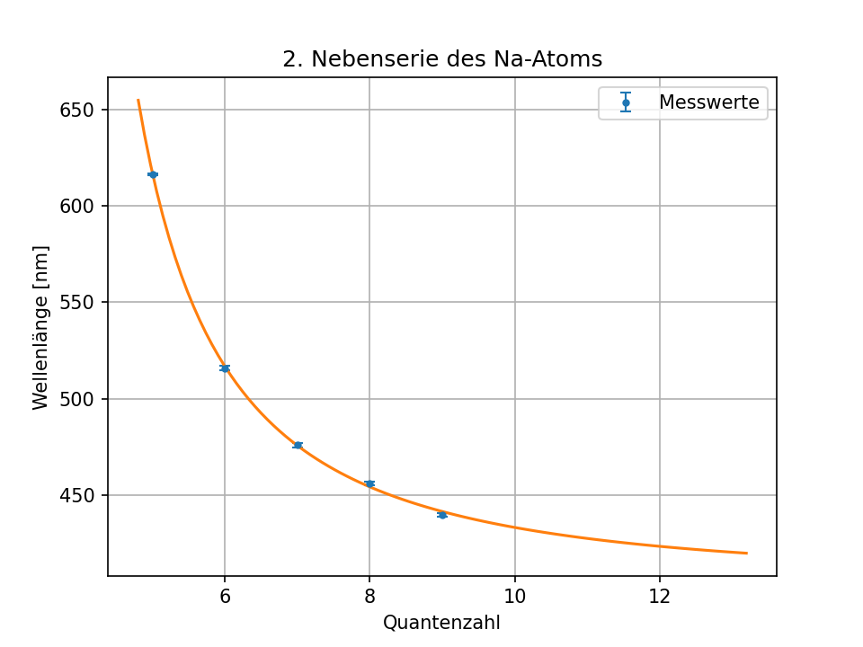

```python
def fit_func2(m,E_Ry,E_3p,korrs):
    return 1.2398E3/(E_Ry/(m-korrs)**2-E_3p)
para = [-13.6,-3,-0.02]
popt, pcov = curve_fit(fit_func2,Nebenserie2m,Nebenserie2_wellen,sigma=Nebenserie2_wellenfehler,p0=para)
x=np.linspace(4.8,13.2, 100)

plt.figure(dpi=150)
plt.errorbar(Nebenserie2m,Nebenserie2_wellen,yerr=Nebenserie2_wellenfehler,fmt=".",capsize=3,elinewidth=1,label='Messwerte')
plt.plot(x,fit_func1(x,*popt))
plt.xlabel('Quantenzahl')
plt.ylabel('Wellenlänge [nm]')
plt.title('2. Nebenserie des Na-Atoms')
plt.legend()
plt.grid()
plt.savefig(Ausgabe_path/"Nr.3_Nebenserie2.png", format="png")

print("E_Ry=",popt[0], ", Standardfehler=", np.sqrt(pcov[0][0]))
print("E_3p=",popt[1], ", Standardfehler=", np.sqrt(pcov[1][1]))
print("D_s=",popt[2], ", Standardfehler=", np.sqrt(pcov[2][2]))

chi2_=np.sum((fit_func1(Nebenserie2m,*popt)- Nebenserie2_wellen)**2/ Nebenserie2_wellenfehler**2)
dof=len(Nebenserie2m)-3 #dof:degrees of freedom, Freiheitsgrad
chi2_red=chi2_/dof
print("chi2=", chi2_)
print("chi2_red=",chi2_red)

prob=round(1-chi2.cdf(chi2_,dof),2)*100
print("Wahrscheinlichkeit:", prob,"%")
```